# Reproducibility Assignment

## Cleaning Up Data

First, I read in the data and changed the dates to class Date.

```r
setwd("C:/Users/Michael/Documents")
data=read.csv("activity.csv")
data$date=as.Date(data$date,"%Y-%m-%d")
data[,"Index"]=1:nrow(data)
data$day=weekdays(data$date)
```

## Question 1

Here is a barplot of total number of steps by day

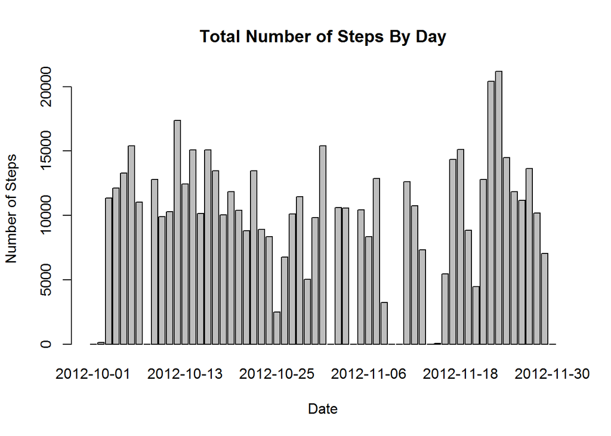

```r
sums=with(data,tapply(steps,date,sum,na.rm=TRUE))
barplot(sums,names.arg=names(sums),main="Total Number of Steps By Day",ylab="Number of Steps",xlab="Date")
```

I then calculated the mean and median over all days.

```r
medians=median(sums,na.rm=TRUE)
means=mean(sums,na.rm=TRUE)
means
```

```
## [1] 9354
```

```r
medians
```

```
## [1] 10395
```

Mean was 9354.2295 and median was 10395.

## Question 2

Here, I plot Steps for each 5 minute interval.

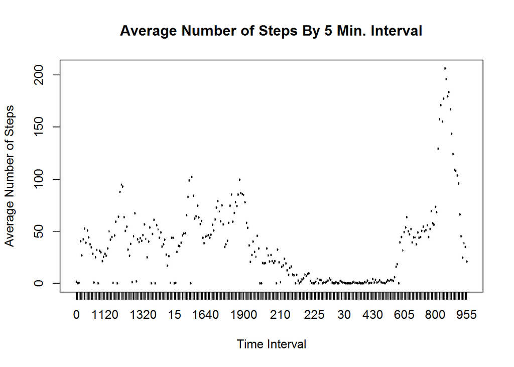

```r
means5min=with(data,tapply(steps,interval,mean,na.rm=TRUE))
means5min=data.frame("interval"=names(means5min),"means"=means5min)
plot(means5min$interval,means5min$means,main="Average Number of Steps By 5 Min. Interval",ylab="Average Number of Steps",xlab="Time Interval",type="l")
```

I found the interval with maximum steps.

```r
max_interval=which(means5min$means==max(means5min$means),arr.ind=TRUE)
max=as.numeric(as.character(means5min[max_interval,"interval"]))
max
```

```
## [1] 835
```

The maximum interval was 835.

## Question 3

I counted the number of rows with NAs

```r
NAcount=sum(!complete.cases(data))
NAcount
```

```
## [1] 2304
```

The number of NAs was 2304

Here, I created a new dataset with the NA’s replaced by the average steps averaged over each interval.

```r
data2=merge(data,means5min,id="interval")
data2=data2[order(data2$Index),]
data2$steps=ifelse(is.na(data2$steps),data2$means,data2$steps)
```

Then, I created a plot of total steps for each day, with the new data.

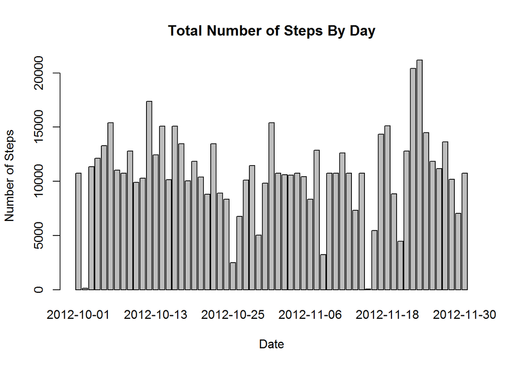

```r
sums2=with(data2,tapply(steps,date,sum,na.rm=TRUE))
barplot(sums2,names.arg=names(sums2),main="Total Number of Steps By Day",ylab="Number of Steps",xlab="Date")
```

I calculated the mean and median over each day with the new data.

```r
medians2=median(sums2)
means2=mean(sums2)
medians2
```

```
## [1] 10766
```

```r
means2
```

```
## [1] 10766
```

## Question 4

I created a new factor variable in my new dataset to differentiate between weekend and weekday data

```r
data2[,"day"]=ifelse(data2[,"day"] %in% c("Sunday","Saturday"),"Weekend","Weekday")
data2$factor=factor(data2$day)
```

I created a panel plotting Steps over each 5 minute interval. I separated the weekend and weekday data first…

```r
weekdays=subset(data2,data2$day %in% "Weekday")
weekends=subset(data2,data2$day %in% "Weekend")
Weekday5min=with(weekdays,tapply(steps,interval,mean,na.rm=TRUE))
Weekday5min=data.frame("interval"=names(Weekday5min),"means"=Weekday5min)
Weekend5min=with(weekends,tapply(steps,interval,mean,na.rm=TRUE))
Weekend5min=data.frame("interval"=names(Weekend5min),"means"=Weekend5min)
```

Then I plotted the data shown below.

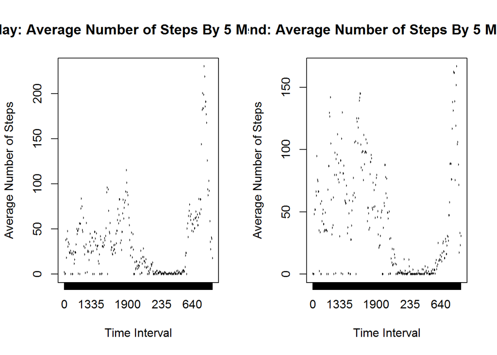

```r
par(mfrow=c(1,2))
plot(Weekday5min$interval,Weekday5min$means,main="Weekday: Average Number of Steps By 5 Min. Interval",ylab="Average Number of Steps",xlab="Time Interval",type="l")
plot(Weekend5min$interval,Weekend5min$means,main="Weekend: Average Number of Steps By 5 Min. Interval",ylab="Average Number of Steps",xlab="Time Interval",type="l")
```